# # ArundelStat Analyst Interview Test Dataset

### 1.5 Geographic effects

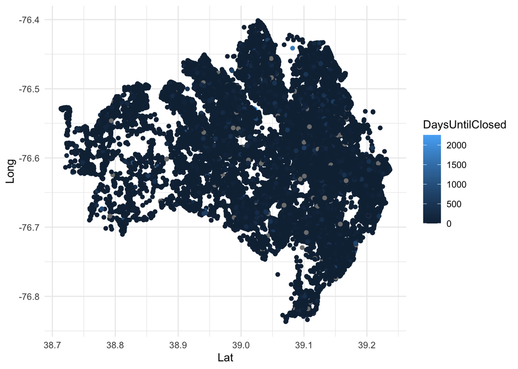

```r
# possible geographic effect to length of time taken for issues
ggplot(data, aes(x = Lat, y = Long, color = DaysUntilClosed)) + geom_point() + theme_minimal()
```

[figure not shown]

```r
ggplot(data, aes(x = Lat, y = Long, color = RequestTypeTitle)) + geom_point() + theme_minimal()
```

### 1.6 Datetime timeframes

- View overlapping timeframe plots for created, updated, acknowledged, reopened, closed

## 2. Exploratory Data Analysis

### 2.1 Group existing and create new features

1. Categorical columns to be factorized: “RequestTypeTitle”, “IssueType”, “Department”, “Subdivision”, “ContactGroupPerson”, “ReportMethod”, “ReportSource”, “Rating”
2. Numerical metrics: updated, created, acknowledged, reopened, closed in datetime format so need to convert to numeric for calculation
- updated-created *(DaysUntilUpdated)*, acknowledged-created (DaysUntilAcknowledged), reopened-created *(DaysUntilReopened)*, closed-created (DaysUntilClosed)
- closed-updated *(DaysSinceUpdated)*, closed-acknowledged *(DaysSinceAcknowledged)*, closed-reopened *(DaysSinceReopened)*, closed-created (DaysUntilClosed)
3. Geographical terms: address, lat, long

```r
factors <- c("RequestTypeTitle", "IssueType", "Department", "Subdivision", "ContactGroupPerson", "ReportMethod", "ReportSource", "Rating")
# also factorize columns
for (col in factors) {
  # Get the column as a factor
  data[[col]] <- as.factor(data[[col]])
}
# add new numeric features from datetime
```

## 2.2 View exploratory plots

```r
# bar plots: status, type, category (ggplot2, plotly)
```

Feature matching *how do request type ID (60), request type title (74), and issue type (52) match up with each other?*

Correlations between numeric columns *add heatmap/pairplot*

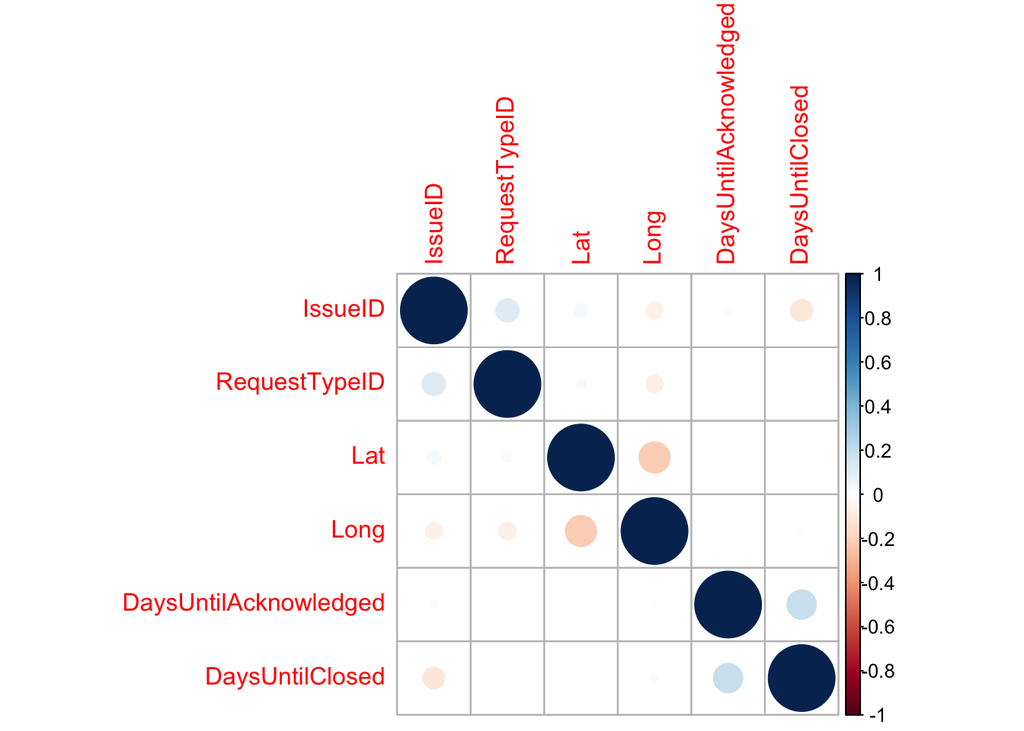

```r
# correlation matrix
numeric_cols <- select_if(data, is.numeric)
cor_matrix <- cor(numeric_cols, use = "complete.obs")
corrplot(cor_matrix, method = "circle")
```

Observe skewness/normality

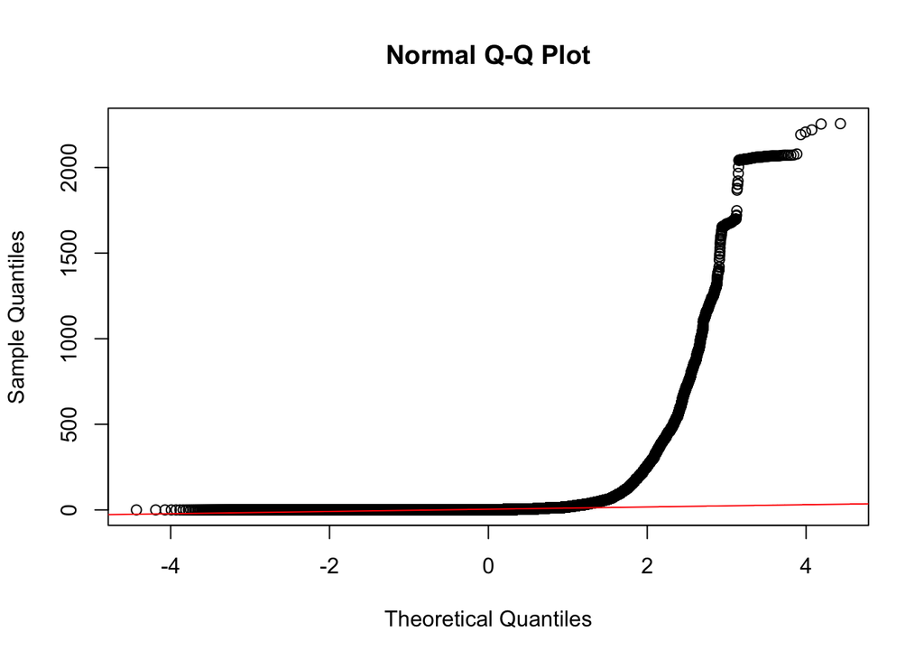

```r
plot.new()
qqnorm(data$DaysUntilClosed)
qqline(data$DaysUntilClosed, col = "red")
```

```r
# Rating and DaysUntilClosed/Acknowledged seem highly skewed, Lat and Long much less so
# how to resolve outliers with rating and DaysUntil features?
```

Potential Binning if necessary: - Bin DaysUntilCLosed and check standard deviation and mean values by grouping  
- bin DaysUntilClosed to see that almost all issues resolve in the lowest interval of 3 bins of time, but have to pay attention to those that take the highest amount of time

```r
data$days_bin <- cut(data$DaysUntilClosed, breaks = 3, labels = c("Low", "Medium", "High"))
table(data$days_bin)
```

```
##
##    Low Medium   High
## 106469    432    191
```

### 2.4 Time to N

- when summarizing factor columns by the average days taken to close issues, the issues that took the longest time to close were related to Vehicles, Cable Services, Infrastructure, Permits, OIT, P&Z, and Constituent Services
- why do vehicles and cable services take so long to close?

```r
factors <- c("IssueStatus", "RequestTypeTitle", "IssueType", "Department", "Subdivision", "ContactGroupPerson", "ReportMethod", "ReportSource")
for (col in factors) {
  sorted_table <- data %>%
    group_by(data[[col]]) %>%
    summarise(mean_days = mean(DaysUntilClosed, na.rm = TRUE), sd_days = sd(DaysUntilClosed, na.rm = TRUE)) %>%
    arrange(desc(mean_days)) %>%
    rename(!!col := `data[[col]]`)
  #cat("Column:", col, "\n")
  print(sorted_table)
}
```

```
## # A tibble: 1 × 3
##   IssueStatus mean_days sd_days
##   <chr>           <dbl>   <dbl>
## 1 Archived         25.6    119.
## # A tibble: 74 × 3
##    RequestTypeTitle                                       mean_days sd_days
##    <fct>                                                      <dbl>   <dbl>
##  1 Unregistered or Inoperable Vehicle on Private Property     246.     450.
##  2 Cable Service                                              205.     413.
##  3 Road Construction                                          179.     397.
##  4 Junk Violation                                             169.     353.
##  5 Septic System - Sewage overflow                            161.     354.
##  6 Stagnant Swimming Pool                                     147.     319.
##  7 Chickens/Roosters/Fowl                                     134.     256.
##  8 Other Concerns                                             111.     316.
```

[output cut: 87 more lines]

### 2.5 Geographical Distributions

```r
# heatmap: density of requests by location (leaflet, sf)
# clustering: cluster areas with high issue density (kmeans, DBSCAN)
```

## 3. Predictive Modeling

### 3.1 Classification

```r
# use features (type, category, dept, days taken) to classify issues as open or closed (caret, glm, RandomForest)
```

### 3.2 Regression

```r
# use features (type, category, department, division, latitude, longitude) to predict days taken (linreg, gradientboosting)
```

## 4. Interpret Insights

## 5. Organize Outputs